# S4 Informe P2

Tema:

**La expectativa de ingreso salarial de estudiantes de la Universidad de Ingeniería y Tecnología en diversas especialidades**

Introducción

Relevancia

La información sobre el mercado laboral de jóvenes que recién egresan de las universidades es muy importante al momento de empezar a buscar empleo en nuestro país, más aún en los últimos años, marcados por un contexto global de mucha inestabilidad resultado de la pandemia, la crisis por el conflicto armado entre Rusia e Ucrania y por el gobierno nacional con un creciente rechazo por sus actos muy asociados a hechos de corrupción.

Existen diversas publicaciones en Internet que nos muestran los ingresos promedio, los rangos máximos y mínimos de ingresos en soles para recién egresados o las carreras mejor pagadas en nuestro país, datos sin duda interesantes para nosotros como estudiantes de la UTEC. Por ejemplo, el portal ponte en carrera destaca como la especialidades de mayor ingreso promedio a los egresados de Estadística con S/. 3,403 y Medicina con S/. 3,107. Por otro lado, también contamos con información oficial del BCRP en el cual nos muestran los ingresos promedio del sector formal a marzo del 2022 asciende a S/. 3,983.80.

Nuestra investigación busca establecer, mediante la aplicación de encuestas a los estudiantes de 12 especialidades de UTEC, sus expectativas de ingresos económicos una vez que egresen de la universidad, además de los intereses de los encuestados por trabajar de manera dependiente o independiente.

La relevancia de nuestra investigación radica en los resultados que obtengamos, si hubo alguna tendencia ascendente o descendente en el contexto global actual de inestabilidad. Además, de establecer estadísticamente los intereses por trabajar de manera dependiente o independiente.

Planificación

Datos:

Recolección de datos

Lo primero que se realizó fue determinar cuál era el propósito de la investigación para así, poder definir las variables que nos permitan recopilar la información necesaria, a través del análisis de éstas. Del mismo modo, descartamos las que no podían ser efectivas en el estudio y ya con las variables esenciales, es decir las finales, se creó un formulario. Mismo que luego de establecer la relevancia y el orden, pasó a ser una encuesta dirigida a los alumnos de la universidad UTEC. Así, se obtuvieron los datos con los que se trabajó durante el proyecto, tales como edad, género, la expectativa salarial y otros, en los que posteriormente se encontró un vínculo entre ellos. Contar con una encuesta virtual nos iba a evitar la labor de realizar encuestas de manera presencial, además de la posibilidad de poder llegar a más alumnos de los que de manera física se hubiera podido llegar. No solo por la situación del sistema híbrido de la universidad, en el que la población estudiantil que iba a la universidad se había reducido, también porque era posible encontrarnos con quienes no deseen participar de la encuesta; por ello, resultó más sencillo enviar las encuestas mediante el correo académico. Al tratarse de la expectativa salarial de los alumnos de pregrado de UTEC, el correo con la encuesta iba dirigido únicamente a ellos pues era nuestra población de estudio, el rango era desde el primer hasta el último ciclo de todas las carreras. Sobre las condiciones, como ya es mencionado, una de las condiciones para realizar la encuesta, fue que solo la podían llenar quienes estudien en UTEC. Finalmente, una de las estrategias para llegar a la población ha sido el correo electrónico de manera grupal, para así poder llegar a cubrir la cifra necesaria y la segunda, fue capturar la atención de los posibles encuestados mediante la realización de un sorteo.

Población, muestra y muestreo

La población de estudio fueron los estudiantes de pregrado de todos los ciclos de la Universidad de Ingeniería y Tecnología (UTEC) y la unidad muestral serían estudiantes de la misma universidad. El tamaño de la muestra es de 202; se designa esta cantidad como muestra representativa, realizando así proyecciones con los resultados arrojados por este número de encuestados. De esta cifra, se cuenta con una representación de un 38,1% para las mujeres y un 61,9% de hombres, teniendo así una proporción próxima al número de integrantes de cada género.

Ahora bien, respecto al tipo de muestreo, se estaría hablando de un muestreo no probabilístico, en específico un muestreo por conveniencia ya que, mediante esta técnica se pueden crear muestras en base a la facilidad de acceso y la disponibilidad de las personas para que formen parte de la muestra. Si bien es cierto que la elección no se de manera directa, si es cierto que los encuestados fueron seleccionados por la proximidad hacia nosotros tratándose de estudiante a estudiante, por consiguiente, se nos facilitó el envío a los alumnos de todas las carreras y del mismo modo, compartirla con los compañeros de la universidad. Podemos decir también que otra razón para considerar que es un muestreo por conveniencia es que, esta población nos favorece ya que sus respuestas aportan al tema de investigación y por tanto, nos resultaría más sencillo analizar las respuestas e interpretarlas. Se empleó debido a que lo que se requería era contar con un grupo de alumnos, los que vendrían a ser la muestra, de la población estudiantil existente en el ciclo 2022 para así tener al alcance respuestas que pueden coincidir con la población.

Variables

-La variable “edad” es del tipo cuantitativa discreta y su restricción es que sea un número entero no negativo.

-La variable “sexo”, es del tipo cualitativa binaria ya que solo responde a dos opciones y su restricción es que sea únicamente dos alternativas.

-La variable “¿Su familia posee alguna empresa en la que usted pueda trabajar en un futuro?” responde al tipo de cualitativa binaria y su restricción es limitarse al sí y no.

-La variable “¿Tiene pensado trabajar en una empresa o formar su propia empresa?”esto responde al tipo de cualitativa binaria y su restricción es limitarse al sí y no.

-La variable “¿Planeas trabajar en el país o ir al extranjero?” es del tipo cualitativa nominal y su restricción son las opciones ya establecidas.

-La variable “¿En qué sector laboral esperas trabajar?” es del tipo cualitativa nominal y su restricción son, además de las opciones dentro de la encuesta, que son los únicos dos sectores.

-La variable “¿Estás interesado en llevar una especialización en empresas?” es una variable cualitativa binaria y su restricción está definida por los dos monosílabos.

-La variable “¿Cuál es su expectativa salarial teniendo como mínimo S/.1025 y como máximo S/.6500 soles? (coloque su respuesta solo números ejemplo: 2500)” es una variable es del tipo cuantitativa discreta y su restricción es que sea un número entero no negativo.

Limpieza de base de datos

Realizamos la limpieza de datos con las cuales podremos tener una base da datos con la cual se pueda realizar la creación de gráficos, obtener la relacion entre las variables, encontrar las medidas de tendencia central.

- Importamos las librerias necesarias para leer la base de datos

- Importamos la base de datos

- Arreglamos las Variables, cambiando el nombre a las variables para una mas fácil identificación

- Cambiamos el tipo de variable de edad, la convertimos en numérica

- Arreglamos los datos, recodificando cada variable

- Eliminamos variables, ya que tenemos algunas filas en blanco

- Determinamos casos y datos incompletos:

```
## [1] 3
```

```
## [1] 3
```

Determinamos casos y datos completos

```
## [1] 2017
```

```
## [1] 199
```

**Analisis descriptivo**

Para la recolección de datos se toma en consideración el uso de variables categóricas y numéricas con el cual realizaremos un análisis de datos mas profundo con las técnicas y las herramientas adecuadas, mismas que nos brindan múltiples beneficios en el análisis de nuestra investigación, entre las variables que destacan en nuestra investigación sobre *La expectativa salarial de los estudiantes en UTEC* son las siguientes:

*Tabla 3*

TABLA NUMERO 3

| valor | tipo | escala |
| --- | --- | --- |
| Edad | Numerica | Discreta |
| Sexo | Categorica | Nominal |
| Ciclo | Categorica | Ordinal |
| Carrera | Categorica | Nominal |
| Empresa Familiar | Categorica | Ordinal |
| Trabajar en una empresa o emprender | Categorica | Nominal |
| Trabajara en | Categorica | Nominal |
| Sector Laboral futuro | Categorica | Nominal |
| Llevara una especializacion en empresas | Categorica | Nominal |
| Expectativa Salarial | Numerica | Continua |

Analisis de las variables edad y ciclo

Análisis de las variables edad

Datos de la variabale edad

| Media | Mediana | Moda1 | Moda.2 | Desviacion.estandar | Varianza |
| --- | --- | --- | --- | --- | --- |
| 19.91 | 20 | 20 | 18 | 1.93 | 3.72 |

Según el análisis a la variable “edad” de nuestra base de datos recopilados en la encuesta sobre “Expectativa salarial de los estudiantes de Utec”, tenemos que el promedio de la edad de los estudiantes encuestados sobre su expectativa salarial está dada por un valor igual a 19.91; el valor medio o mediana de las edades de dichos estudiantes están alrededor de 20; la frecuencia o moda de las mismas edades de todos los encuestados es igual a dos valores, 20 y 18, de los cuales se observa que presenta una frecuencia bimodal en el cual dicha moda es representada por un total de 44 estudiantes del total de encuestados; la desviación estándar de las edades de todos los encuestados es representada por un valor igual a 1.93 con el cual deducimos que el valor de error de la media en los datos analizados es menor y por ello la estimación del valor de la media de la población estudiada presenta mayor precisión y por último tenemos la variación que es representada con un valor igual a 3.72, con este valor podemos concluir que la dispersión de los datos es menor.

Análisis de la variable ciclo

Datos de la variabale ciclo

| Media | Mediana | Moda | Desviacion.estandar | Varianza |
| --- | --- | --- | --- | --- |
| 4.8 | 5 | 3 | 2.41 | 5.8 |

*Tabla 4*

TABLA NUMERO 4

|  | Femenino | Masculino |
| --- | --- | --- |
| Ciencia de la Computación | 6 | 18 |
| Ingeniería Industrial | 10 | 21 |
| Ingeniería Mecatrónica | 4 | 19 |
| Ingeniería Civil | 7 | 17 |
| Ingeniería Química | 7 | 5 |
| Ingeniería Electrónica | 6 | 10 |
| Ingeniería Mecánica | 1 | 6 |
| Bioingeniería | 12 | 3 |
| Administración y Negocios Digitales | 7 | 7 |
| Ingeniería de la Energía | 5 | 5 |
| Ingeniería Ambiental | 11 | 10 |
| Ciencia de Datos | 1 | 4 |
| total | 77 | 125 |

*Expectativa empresarial de los estudiantes UTEC*

En esta parte analizaremos la relación que existe entre las variables “Empresa familiar” y “Trabajar en una empresa o emprender” con la cantidad de personas por cada sector.

*Grafico 1*

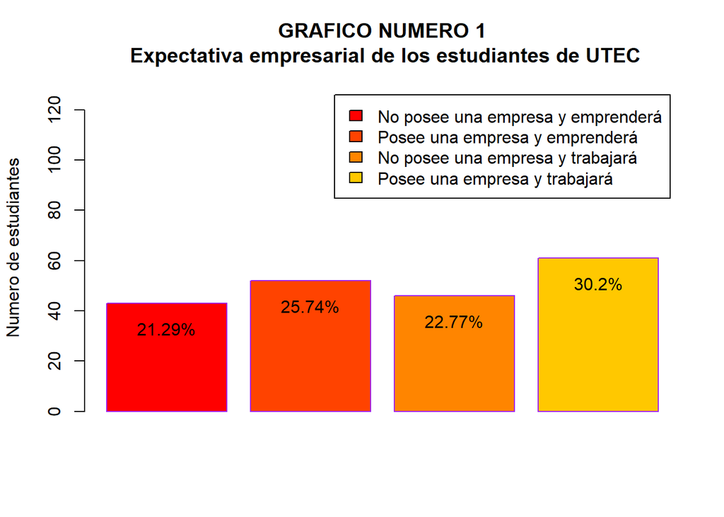

*Plan de trabajo a futuro de los estudiantes de UTEC*

El siguiente gráfico mostraremos el porcentaje la cantidad de estudiantes que trabajaran en un sector publico o privado con si lo ejercerá en Perú o en extranjero.

*Grafico 2*

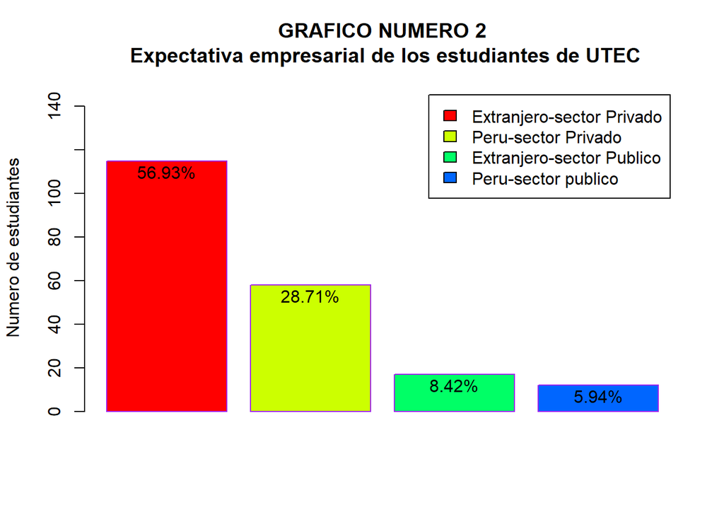

*Análisis a la variable de expectativa salarial*

Datos de la variable expectativa salarial

| Media | Mediana | Moda |
| --- | --- | --- |
| 4948.59 | 4900 | 6500 |

Por último tenemos como variable de análisis a la variable ” expectativa salarial” en el cual el valor promedio de esta misma es igual a 4948.59 el cual representa un valor promedio de la expectativa que tienen los estudiantes en función a las diferentes carreras que estén cursando; el valor medio o mediana de la misma es igual a 4900 que también representa la expectativa salarial del total de encuestados y por último tenemos que el valor de la moda viene dado por 6500 el mismo que representa la mayor frecuencia de la expectativa salario que tienen los estudiantes encuestados de UTEC, mismo que es representado por un valor total de 32 estudiantes que tienen esta expectativa salarial de acuerdo a la carrera que estén llevando.

Para Observar el sesgo de la variable y los datos atípicos lo representaremos en un gráfico de cajas

*Grafica 3*

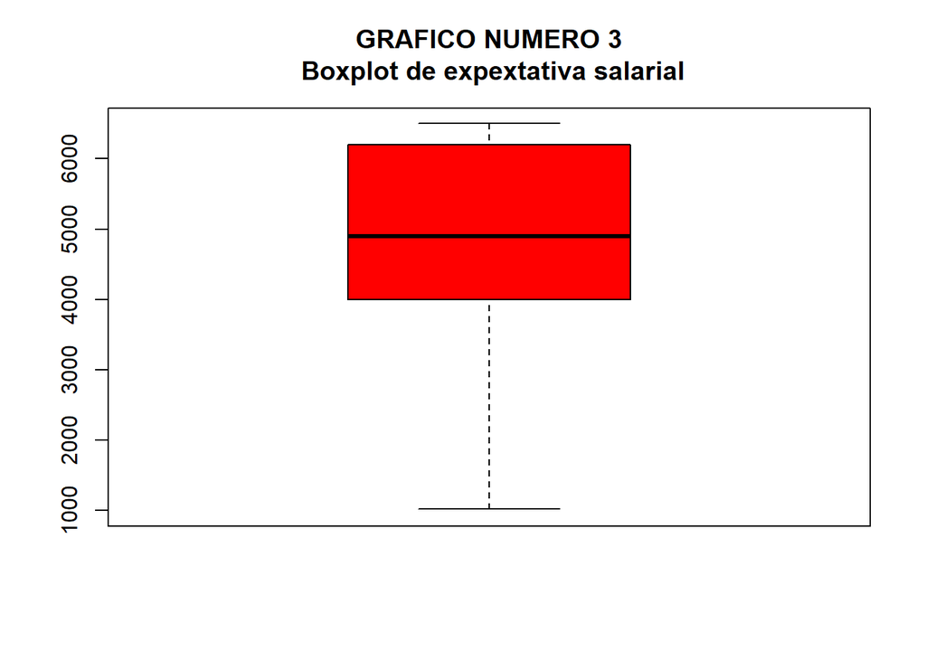

*Análisis de regresión lineal entre la variables edad y expectativa salarial*

*Grafica 4*

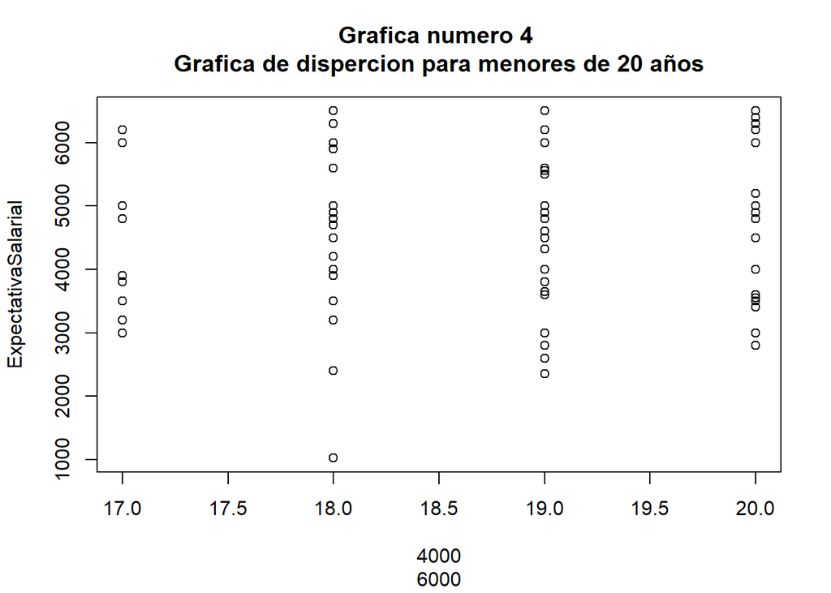

*Grafica 5*

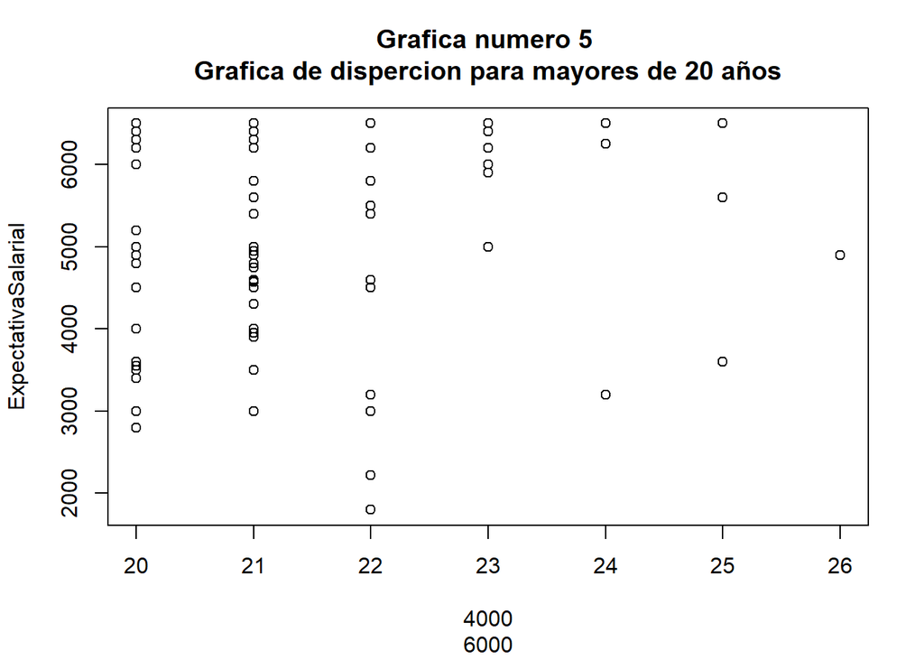

*Grafica 6*

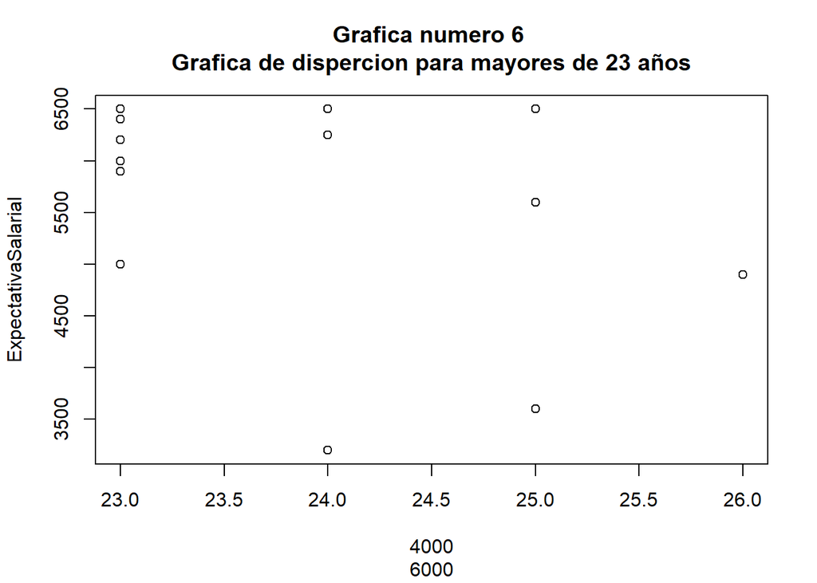

Podemos observar que las gráficas tienen una correlación muy baja entre ellas,por ello, no se puede analizar una muestra de regresión lineal ya que los datos están muy dispersos y no muestran una correlación entre ellas, sin embargo realizamos el gráfica pero no logramos obtener ningún dato relevante para nuestro estudio con nuestras variables numéricas, incluso se realizaron gráficos de dispersión con diferentes rangos, sin embargo no logramos obtener información relevante para el estudio.

Análisis comparativo

Tablas cruzadas Para ello debemos realizar una recodificación de nuestra base de datos, agrupando los valores de los salarios en rangos, para lograr colocarlos en nuestras tablas cruzadas, en la cuales los compararemos con variables como : Carrera, especialización en empresas, sexo, sector laboral.

Tablas Cruzadas:

Carrera vs Expectativa Salarial

*Tabla 4*

TABLA CRUZADA NUMERO 4 -> CARRERA-EXPECTATIVA SALARIAL

|  | De S/.3000 a S/.5000 | Más de S/.5000 | Menos de S/.3000 | total_col |
| --- | --- | --- | --- | --- |
| Ciencia de la Computación | 10 | 13 | 1 | 24 |
| Ingeniería Industrial | 15 | 13 | 3 | 31 |
| Ingeniería Mecatrónica | 9 | 12 | 2 | 23 |
| Ingeniería Civil | 13 | 9 | 2 | 24 |
| Ingeniería Química | 6 | 2 | 4 | 12 |
| Ingeniería Electrónica | 9 | 5 | 2 | 16 |
| Ingeniería Mecánica | 3 | 4 | 0 | 7 |
| Bioingeniería | 11 | 4 | 0 | 15 |
| Administración y Negocios Digitales | 8 | 5 | 1 | 14 |
| Ingeniería de la Energía | 4 | 4 | 2 | 10 |
| Ingeniería Ambiental | 11 | 10 | 0 | 21 |
| Ciencia de Datos | 3 | 2 | 0 | 5 |
| total_fi | 102 | 83 | 17 | 202 |

En esta tabla se puede observar cómo es que dentro de cada carrera, los estudiantes tienen diferentes aspiraciones salariales, por lo que podemos deducir que esta diversidad puede estar influenciada por el ciclo en el que se encuentra el alumno al no conocer la realidad de la remuneración o también por el hecho de considerar llevar una especialización que mejore la expectativa salarial que tenían. Asimismo, se puede observar que los estudiantes que pretenden obtener un ingreso que oscila entre los 3000 y 5000,pertenecen a la carrera de ingeniería industrial, seguido de ingeniería civil y en tercer lugar la carrera de ingeniería ambiental. Se puede apreciar también que justamente en esta última carrera, bioingeniería, ciencia de los datos e ingeniería mecánica, los alumnos no pretenden ganar menos de los 3000 soles.

Especialización en Empresas vs Expectativa salarial

*Tabla 5*

TABLA CRUZADA NUMERO 5 -> ESPECIALIZACION EN EMPRESAS-ExPECTATIVA SALARIAL

|  | De.S..3000.a.S..5000 | Más.de.S..5000 | Menos.de.S..3000 | total_espec |
| --- | --- | --- | --- | --- |
| Sí | 51 | 45 | 9 | 105 |
| No | 51 | 38 | 8 | 97 |
| total_espectativa | 102 | 83 | 17 | 202 |

En esta tabla se observa que existen una gran cantidad de alumnos, aproximadamente 52%, que no pretenden llevar una especialización pero que aún así aspiran a llegar a percibir ingresos entre los 3000 y 5000 soles; una menor cantidad con el 39% que prefiere no llevar especialización desea tener una ingreso mayor a los 5000 soles, mientras que un 8.2%, sin especialización aspira a un ingreso menor a los 3000 soles. Del otro lado, para aquellos que sí desean llevar una especialización, se observa que el 48.5% un equivalente a 51 estudiantes, tiene como expectativa salarial un monto que se encuentra entre los 3000 y 5000 soles, mientras que una cantidad mucho mayor: 42.8% en comparación a los que no prefieren llevarla, pretende ganar más de 5000. Sin embargo, están también aquellos que aun con especialización tienen como expectativa un ingreso menor a los 3000 soles. En consecuencia, podemos asumir que los alumnos que llevarán posteriormente una especialización tienen una mayor expectativa salarial.

Probabilidad Frecuentista

Si escogemos aleatoriamente un estudiante, determine la probabilidad que,

1. Estudie la carrera de ingeniería industrial y que tenga expectativas salariales mayor S/. 3000 y menores que S/.5000 (Intersección)

P(II∩3000<5000)= 15/202

```
## [1] 0.07425743
```

2. Tenga expectativas salariales mayores a S/. 5000 (Probabilidad Clásica)

P(>5000)= 83/202

```
## [1] 0.4108911
```

)3 Espere un salario de egresado menor a S/.5000 pero mayor a S/.3000, si se sabe que está estudiando la carrera de Ingeniería Mecánica. (Axioma 9 - Probabilidad Condicional) P(3000<5000/IM)= P(3000<5000∩IM)/P(IM)=(3/202)/(7/202)

```
## [1] 0.4285714
```

4. No estudie la carrera de Ciencia de Datos ni que tenga una expectativa salarial mayor a S/.5000 (Axioma 7 - Probabilidad de Morgan) P(CD∩<5000)^c = 1 - P(CDU<5000) = 1 - [P(CD) + P(<5000) - P(CD∩<5000)] = 1-(5/202 + 83/202 - 2/202)

```
## [1] 0.5742574
```

5. Sea de la Carrera de Ingeniería Civil o tenga una expectativa salarial mayor a S/.5000 (Axioma 3 - probabilidad de la Unión) P(ICU>5000) = P(IC) +P(>5000) - P(IC∩>5000) = 24/202 + 83/202 - 9/202

```
## [1] 0.4851485
```

6. Quiera llevar una especialización en empresas.(Probabilidad Clásica) P(E)=N(E)/N(Ω)

```
## [1] 0.519802
```

7 ) No quiera llevar una especialización en empresas.(Probabilidad Clásica) P(NE)=N(NE)/N(Ω)

```
## [1] 0.480198
```

8. No quiera llevar una especialización en empresas y que espere un salario de egresado menor a S/.5000 pero mayor a S/.3000(Intersección) P(3000<5000∩NE)=51/202

```
## [1] 0.2524752
```

9. Tenga una expectativa salarial mayor a S/.5000 sabiendo que sí busca llevar una especialización en empresas.(Axioma 9- Probabilidad condicional) P(5000</E)=P(5000<∩E)/P(E)=(45/202)/(105/202)

```
## [1] 0.4285714
```

10. No quiera llevar una especialización en empresas ni que especule un salario menor a S/.3000 (Axioma 7- Probabilidad de Morgan) P(NE∩3000>)^c= 1 - P(NEU3000>) = 1 - [P(NE) + P(3000>) - P(NE∩3000>)] = 1 - (97/202 + 17/202 - 8/202)

```
## [1] 0.4752475
```

**Modelos**

*Grafica 7*

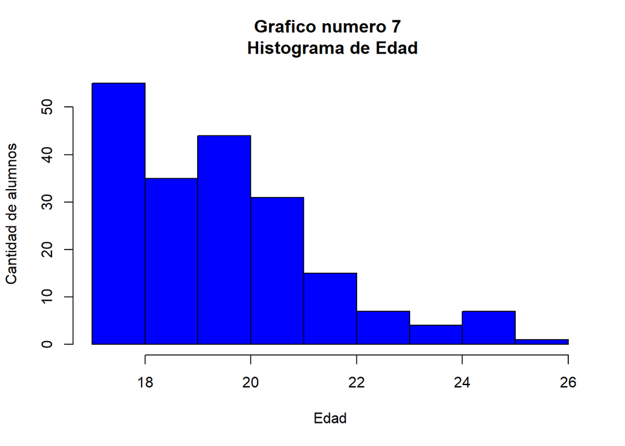

El modelo al cual esta sujeta la gráfica 7 aproximadamente es un modelo exponencial, por la forma dada por el histograma. Para el cual encontramos lamda, dividiendo 1 entre la media de la edad de nuestros entrevistados.

```
## [1] 19.91457
```

```
## [1] 0.05021448
```

Cual es la probabilidad de que al elegir un alumno este alumno tenga una edad menor o igual a 21 años

```
## [1] 0.6516349
```

```
## [1] 0.4258593
```

*Grafica 8*

El modelo al cual esta sujeta la gráfica 8 aproximadamente es un modelo uniforme, por la forma dada por el histograma. Para el cual utilizaremos punif para el calculo de las probabilidades, con lo cual debemos encontrar el mínimo y el máximo de nuestra variable en este caso ingeniería de la energía.

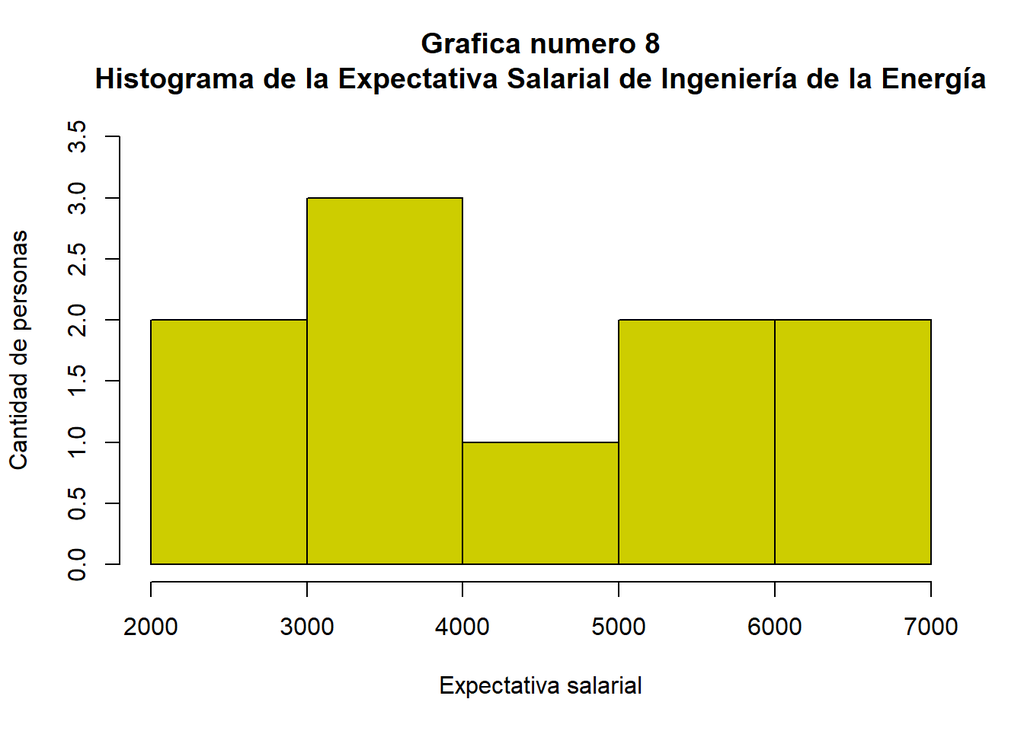

cual es la probabilidad de que al escoger un alumno este sea de ingeniería de la energía y tenga una expectativa salarial mayor a 3500 soles

```
## [1] 0.7088608
```

```
## [1] 0
```

Obtenemos que la probabilidad que al elegir un alumno este sea de ingeniería de la energía y este tenga una expectativa salarial igual a 1250 soles es de 0 ya que si nos fijamos en el histograma y en nuestro valor mínimo esta probabilidad esta fuera del rango lo que nos indica que ningun alumno ha indicado que tiene una expectativa salarial de 1250.

*Grafica 9*

El modelo al cual esta sujeta la gráfica 9 aproximadamente es un modelo binomial, por la forma dada por el histograma. Para el cual utilizaremos pbinom en el calculo de las probabilidades.

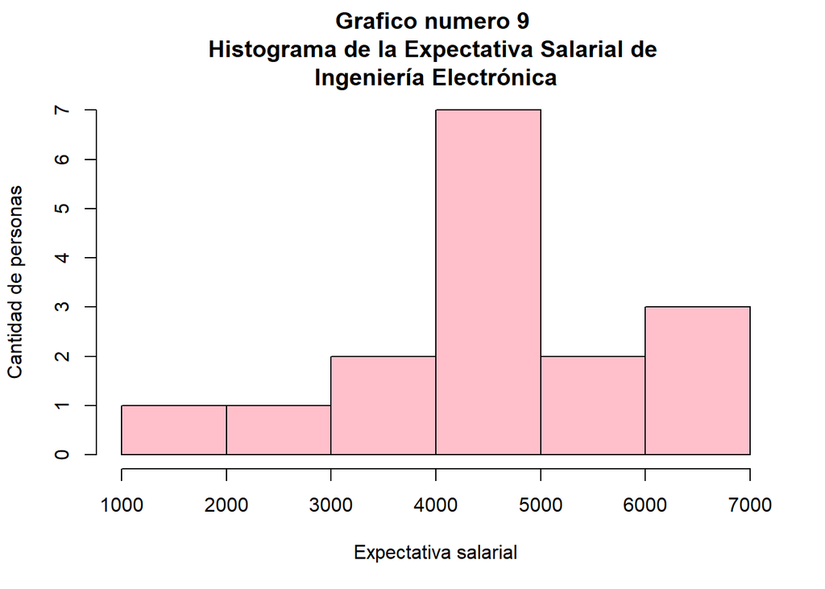

```
## [1] 0.008642629
```

```
## [1] 0.5950129
```

*Bibliográfica*

Ministerio de Educación.(s.f)Carreras Mejor Pagadas en Perú ¿Qué estudiar?. https://estudiaperu.pe/guias/carreras-mejor-pagadas-en-peru/

Banco central de Reserva del Perú.(junio, 2022).Remuneraciones y empleo.https://estadisticas.bcrp.gob.pe/estadisticas/series/mensuales/remuneraciones-y-empleo.